# Anova and Ancova

Gabriel Singer

15.02.2023

# Standard test procedure tables: what is “standard” for a comparison of locations? ;-)

- **Independent samples**
- **Dependent/paired** Measurements can be paired (*aligned*) across time or space for repeatedly measured objects (e.g. same patients before and after a drug).

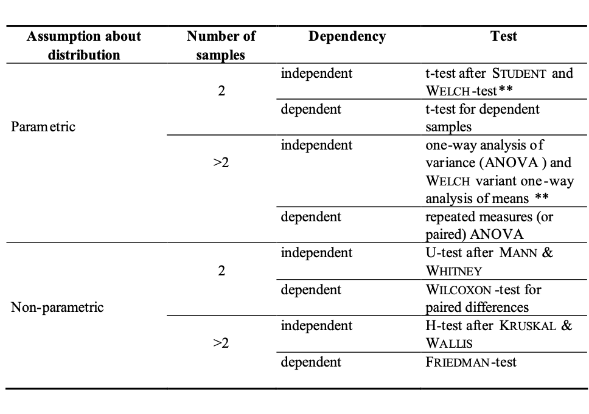

# Parametric vs. non-parametric tests, testing normality

- **Parametric** tests assume applicability of a known parameterized probability distribution, e.g. ND ($\mu$, $\sigma$). Mostly the word is used to describe tests that assume ND for data.
- **Non-parametric** tests do not make any assumption about frequency distributions. They are also called *distribution-free*.

This makes it necessary to **check** normal distribution:

- Compute **skewness and kurtosis**.
- Check relative difference of **mean and median**.
- Plot **histograms**, **boxplots**, **QQ-plots**.
- *Notorious* **Statistical tests** allow a formal test of H0: data is normal.

**Statisticians tend to rely on graphical means!**

Consider data transformation to achieve normally distributed data: Applying the same mathematical operation to all data. Consider $pH=-\log_{10}[H_3O^+]$. A log-normal distribution is very common in ecological/environmental data!

- Data skewed to the left: exponential functions x^2 or x^3, etc.
- Data skewed to the right: $\log(x)$ or $\sqrt(x)$ or $\frac{1}{x}$ or $\frac{1}{x^2}$, etc.
- Data with zeros: $\log(x+min(x))$ where min(x) is often just 1 (especially for count data).

For final graphs and tables, data may be back-transformed into its original units, e.g. $x=e^y$ for $y=\ln(x)$.

# Standard test procedure tables: what is “standard” for a comparison of locations? ;-)

- **Independent samples**
- **Dependent/paired** Measurements can be paired (*aligned*) across time or space for repeatedly measured objects (e.g. same patients before and after a drug).

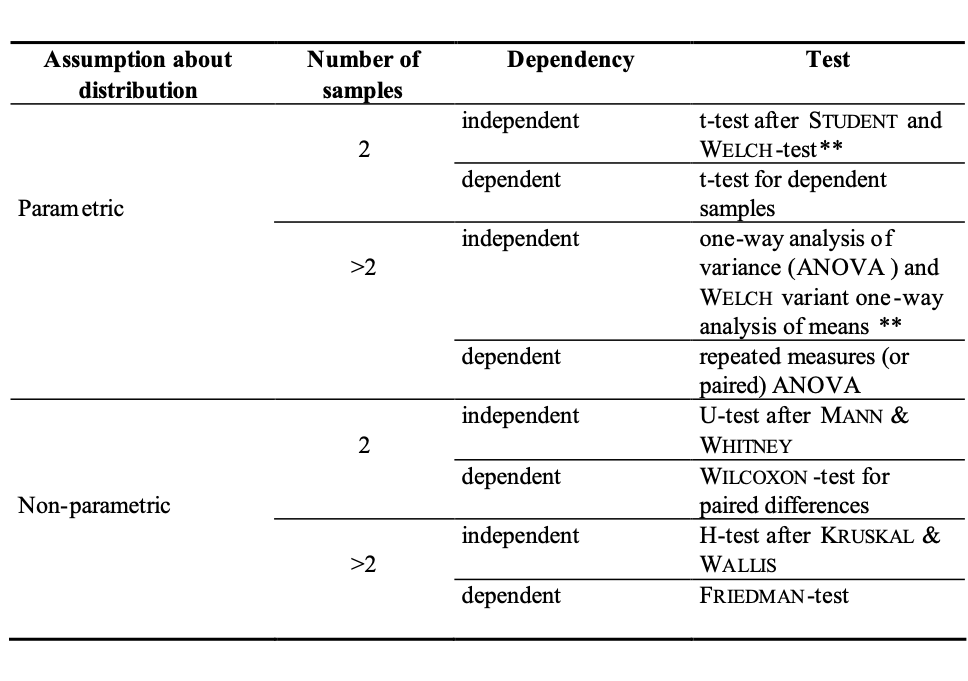

# Multiple comparisons:

What happens if we have more than two groups and all we know is the t-test?

Pairwise testing is possible: For example groups A, B, C might be tested A vs. B, B vs. C, A vs. C.

Two major problems:

1. The amount of work quickly escalates.
2. We repeatedly use the same data - type I error inflates seriously!

What is the real “experimentwise error rate” when doing two tests in sequence?

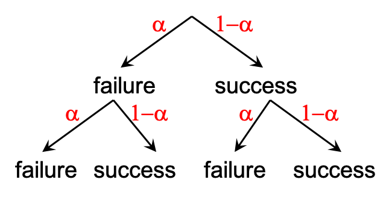

A conservative estimate for the probability to make *any* failure (total error) in multiple test procedures is:

$$\alpha_t=1-(1-\alpha)^k$$
… where $\alpha$ and $\alpha_t$ are alpha errors for any single test and the sequence of $k$ tests.

**Bonferroni**-correction (also known as *Dunn-Sidak*):

$$\alpha_{adj}=1-(1-\alpha_t)^{\frac{1}{k}}$$
with $\alpha_t$ set to a desired level (0.05) this results in an adjusted (lower) $\alpha_{adj}$ to be used for any single test.

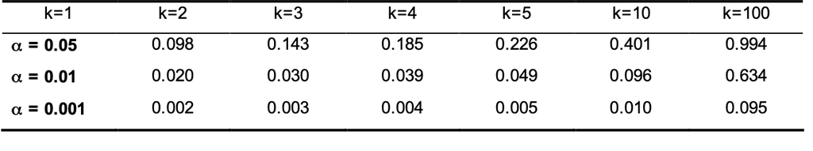

# ANalysis Of VAriance: One-way ANOVA

A parametric test procedure for testing significant differences among means of more than two independent samples from normally distributed populations.

Continuous response variable = dependent.

Categorical group coding variable = independent = factor (groups = factor levels).

Different types of ANOVA:

- ANOVA with more than one factor = multifactorial ANOVA
- ANOVA, where the comparison between groups should be independent of one ore more continuous variables (= covariables) = ANCOVA = ANalysis Of COVariance
- ANOVA with more than one dependent variable = MANOVA = multivariate ANOVA
- ANOVA with dependent samples = Repeated measures ANOVA
- model I ANOVA: with treatment factors (deliberate manipulation)
- model II ANOVA: with random effects (e.g. random replication at multiple levels – fish within cages within ponds)
- mixed model ANOVAs have both treatment factor(s) and random effect(s)

# ANalysis Of VAriance: Assumptions and remedies

1. Response X has to show **normal distribution at each factor level**.
2. **Homogeneity of variances**: More critical! Test with `bartlett.test`.

*When assumption of normal distribution is violated*:

- ANOVA is considered **robust against violations**.
- **Transform** variable, e.g. $\log(x)$.
- **Assume ND**? What do you know about the *population*? Which process generated the data? Reasons to assume random measurement error?
- Switch to **non-parametric procedures**.

*When assumption of variance homogeneity violated*:

- **Transform** variable.
- Switch to **non-parametric test**.
- Run **multiple pairwise comparisons** using t-tests or U-tests and adjust P.
- Use variant of Welch test `oneway.test`.

```r
data<-read.table(file="data/MaraRiver.txt",header=TRUE) # landuse and water chemistry of 54 streams
data$landuse<-factor(data$landuse)   # define factor
levels(data$landuse)
```

```
## [1] "A" "F" "M"
```

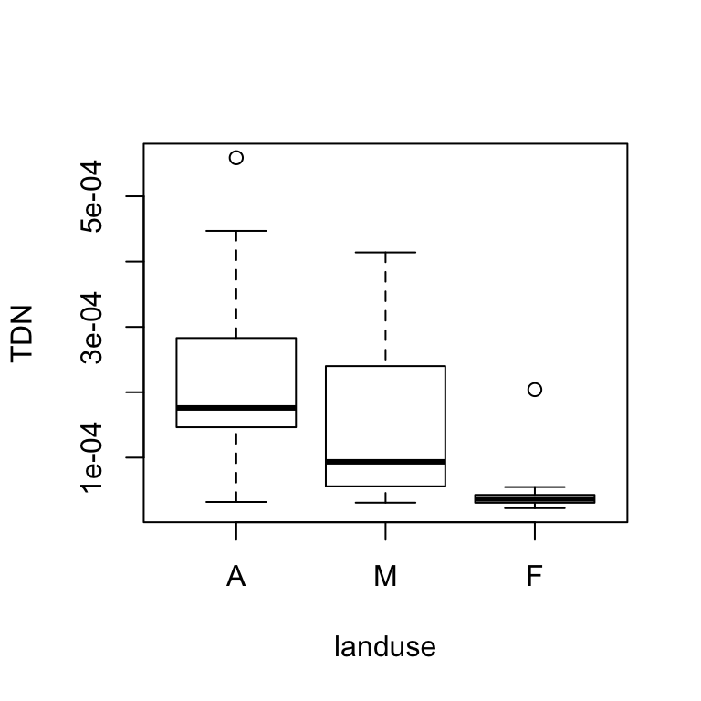

```r
data$landuse<-factor(data$landuse,levels=c("A","M","F"))
# First check ND and variance homogeneity?
boxplot(TDN~landuse,data=data)
```

```r
shapiro.test(data$TDN[data$landuse=="M"]) # also needed for A, F
```

```
##
##  Shapiro-Wilk normality test
##
## data:  data$TDN[data$landuse == "M"]
## W = 0.86275, p-value = 0.02644
```

```r
bartlett.test(TDN~landuse,data=data)
```

```
##
##  Bartlett test of homogeneity of variances
##
## data:  TDN by landuse
## Bartlett's K-squared = 16.736, df = 2, p-value = 0.0002321
```

```r
# -> variances differ significantly among landuses !

# Get out of here ASAP ;-)
oneway.test(TDN~landuse,data=data,var.equal=FALSE)
```

```
##
##  One-way analysis of means (not assuming equal variances)
##
## data:  TDN and landuse
## F = 18.843, num df = 2.000, denom df = 27.735, p-value = 6.79e-06
```

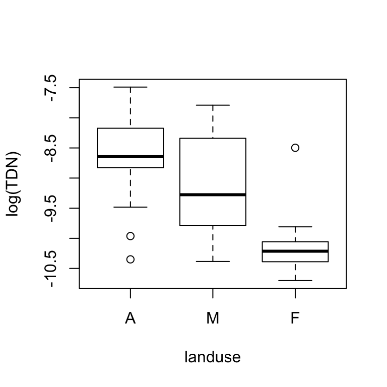

```r
# ... or try again with log-transformed TDN!
boxplot(log(TDN)~landuse,data=data)
```

```r
bartlett.test(log(TDN)~landuse,data=data)
```

```
##
##  Bartlett test of homogeneity of variances
##
## data:  log(TDN) by landuse
## Bartlett's K-squared = 3.2239, df = 2, p-value = 0.1995
```

```r
#-> variances now homogeneous (i.e. "not found heterogeneous")
# ready for ANOVA
```

# ANalysis Of VAriance: Hypotheses

(Illustration assumes 3 groups and equal group sizes n.)

$H_0$: The three groups are not different, i.e. they come from same population. $\mu_1=\mu_2=\mu_3$

$H_A$: At least one group differs from at least one other, i.e. one comes from a different population. $\mu_1\neq\mu_2=\mu_3$ or $\mu_1=\mu_2\neq\mu_3$ or $\mu_1\neq\mu_2\neq\mu_3$.

These hypotheses are here formulated for means (ANOVA), but are similarly formulated for variances (Bartlett-test).

We will use variances to test these hypotheses!

Recall F-distribution built by taking two (!) samples from a population (ND with $\mu,\sigma^2$) and computing:
$$F=\frac{s_1^2}{s_2^2}\sim1$$

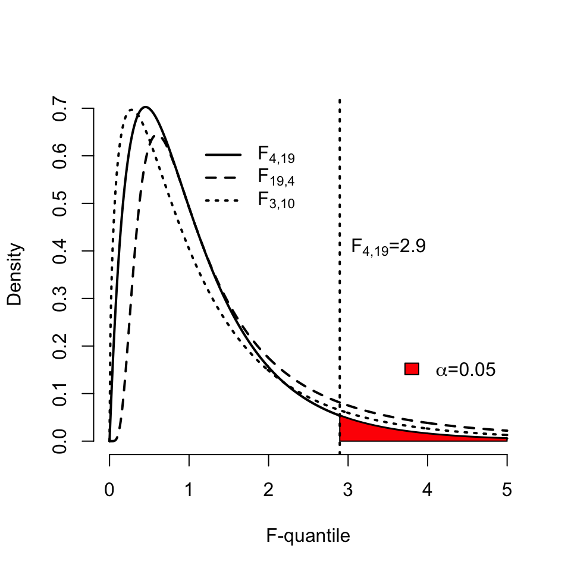

# ANalysis Of VAriance: Graphical scheme

Remember $H_0$ is true :-). Task: Estimate variance from the **ONE** underlying population!

1. Ignore groups, pool data and compute a **total** variance.
2. Compute average of variances **within** each group.
3. Compute **between** (**among**) variance from SEM = standard deviation of group means from grand mean.

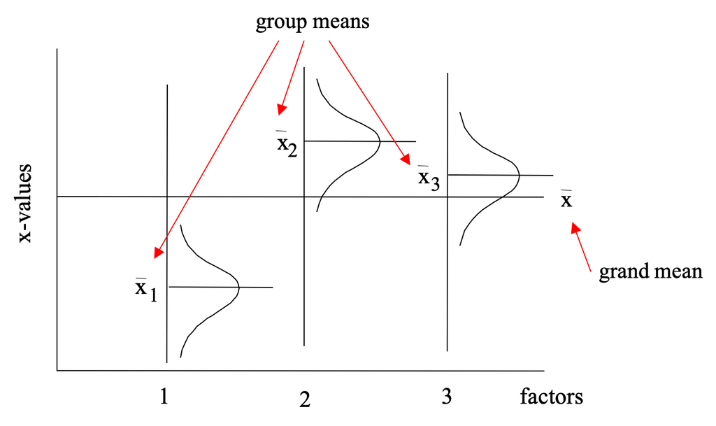

For step 2: Calculation of sum of squares **within** the groups, i.e. the sum of the squared differences between each data point and the respective group mean.

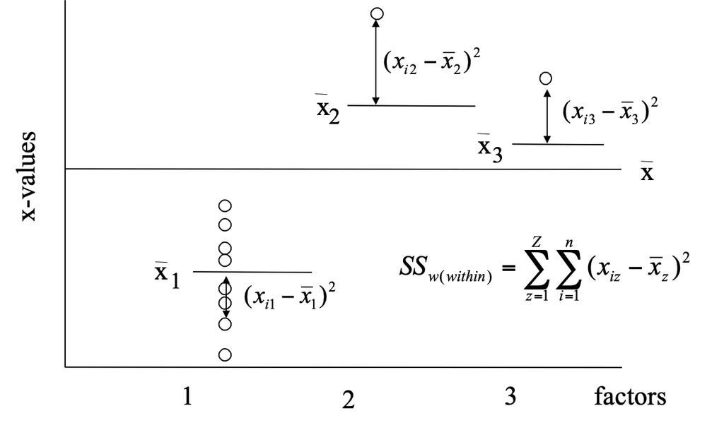

For step 3: Calculation of sums of squares **between** the groups, i.e. the sum of the squared differences between the **group means** and the **grand mean**.

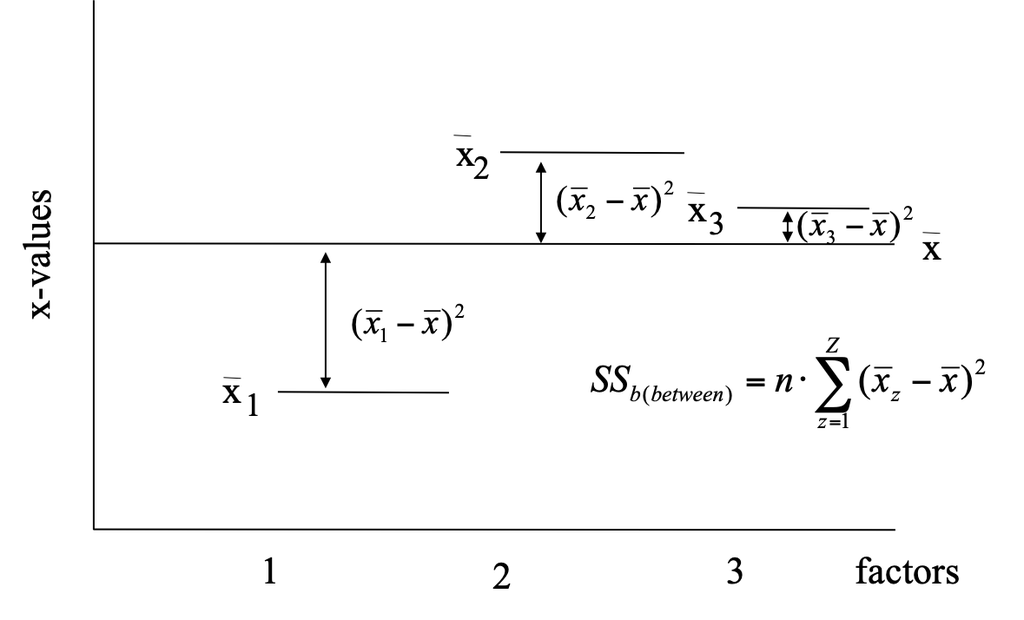

# ANalysis Of VAriance: Partitioning sums of squares

For each strategy to estimate variance an expression for sums of squares is needed:

1. $SS_t$ is always an expression for total variation.

$$SS_{t(total)}=\sum_{z=1}^Z\sum_{i=1}^n(x_{iz}-\bar{x})^2$$

2. $SS_w$ is an expression for within-group variation, also called *not explained* SS (*due to random error*).

$$SS_{w(within)}=\sum_{z=1}^Z\sum_{i=1}^n(x_{iz}-\bar{x}_z)^2$$

3. $SS_b$ is an expression for group-to-group variation, also called the *explained* SS (*due to treatment*).

$$SS_{b(between)}=n\cdot\sum_{z=1}^Z(\bar{x}_z-\bar{x})^2$$

Sums of squares are additive! The variation of the whole dataset is now partitioned into two parts depending on origin!

$$SS_t=SS_b+SS_w$$

This can be translated into percentages of variation due to treatment and due to random error!

The process is also called **Partitioning the total sum of squares (SS) (“Splitting of variance”)**

# ANalysis Of VAriance: Mean squares

Sums of squares are turned into *mean squared deviations* by dividing through the appropriate degrees of freedom:

$$MS_t=\frac{SS_t}{Z\cdot{n}-1}$$
$$MS_w=\frac{SS_w}{Z\cdot{(n-1)}}$$
$$MS_b=\frac{SS_b}{Z-1}$$

All mean squares are **variance estimates**!

Recall that $SEM^2=\frac{s^2}{n}$. As in $SS_b$ the sum of squared group mean deviations from the grand mean was already multiplied with $n$, $MS_b$ estimates $\sigma^2$.

**Under a true $H_0$** all mean squares are good estimates for the same population variance $\sigma^2$.

**Under a true $H_A$**:

1. $MS_w$ is still the average within-group variation and thus estimates $\sigma_1^2=\sigma_2^2=\sigma_3^2$ (variance homogeneity!).
2. $MS_b$ now includes substantial group-to-group variation, its estimate for $\sigma^2$ is larger than expected!

Calculation of the test statistic F:

$$TS=F_{emp}=\frac{MS_b}{MS_w}$$

$F\approx1$ under a true $H_0$, but $F>>1$ when $MS_b$ includes a group effect. A P-value can be computed from F-distribution with $df_1=Z-1$ and $df_2=Z(n-1)$.

**Post-hoc tests**: Pairwise comparisons with adjusted P-values after all!

# ANalysis Of VAriance in R

```r
# using the Mara river data
fit<-aov(log(TDN)~landuse,data=data)
summary(fit)
```

```
##             Df Sum Sq Mean Sq F value   Pr(>F)
## landuse      2  20.93  10.467   22.87 8.14e-08 ***
## Residuals   51  23.34   0.458
## ---
## Signif. codes:  0 '***' 0.001 '**' 0.01 '*' 0.05 '.' 0.1 ' ' 1
```

```r
fit2<-lm(log(TDN)~landuse,data=data)
anova(fit2)
## Analysis of Variance Table
##
## Response: log(TDN)
##           Df Sum Sq Mean Sq F value    Pr(>F)
## landuse    2 20.934 10.4668  22.867 8.141e-08 ***
## Residuals 51 23.343  0.4577
## ---
## Signif. codes:  0 '***' 0.001 '**' 0.01 '*' 0.05 '.' 0.1 ' ' 1
# -> yes, there is a significant landuse effect on log(TDN)

TukeyHSD(fit) # post hoc tests, needs usage of aov() above
```

```
##   Tukey multiple comparisons of means
##     95% family-wise confidence level
##
## Fit: aov(formula = log(TDN) ~ landuse, data = data)
##
## $landuse
##           diff       lwr         upr     p adj
## M-A -0.4678338 -1.009851  0.07418378 0.1033445
## F-A -1.4818796 -2.013546 -0.95021281 0.0000000
## F-M -1.0140458 -1.601003 -0.42708868 0.0003427
```

```r
# check last column for adjusted p-values
pairwise.t.test(log(data$TDN),data$landuse,p.adj="bonferroni",pool.sd=TRUE)
```

```
##
##  Pairwise comparisons using t tests with pooled SD
##
## data:  log(data$TDN) and data$landuse
##
##   A       M
## M 0.12668 -
## F 4.4e-08 0.00035
##
## P value adjustment method: bonferroni
```

```r
# -> F differs from M and A, F has lowest TDN (i.e. "some" agriculture already increases TDN)

# in case of unequal variances: Welch-test variant for >2 groups
# here applied on the non-transformed TDN data
oneway.test(TDN~landuse,data=data,var.equal=FALSE)
```

```
##
##  One-way analysis of means (not assuming equal variances)
##
## data:  TDN and landuse
## F = 18.843, num df = 2.000, denom df = 27.735, p-value = 6.79e-06
```

```r
# should then be followed up by appropriate post-hoc tests
pairwise.t.test(data$TDN,data$landuse,p.adj="bonferroni",pool.sd=FALSE)
```

```
##
##  Pairwise comparisons using t tests with non-pooled SD
##
## data:  data$TDN and data$landuse
##
##   A       M
## M 0.312   -
## F 1.2e-05 0.016
##
## P value adjustment method: bonferroni
```

```r
# -> similar result, but less powerful (P-values are closer to significance threshold)

# in case of no ND and/or unequal variances: H-test after Kruskal and Wallis
# based on ranks, so can be applied on non-transformed TDN data
kruskal.test(TDN~landuse,data=data)
```

```
##
##  Kruskal-Wallis rank sum test
##
## data:  TDN by landuse
## Kruskal-Wallis chi-squared = 24.443, df = 2, p-value = 4.923e-06
```

```r
# appropriate post-hoc tests by multiple U-tests (only possible manually) #
wilcox.test(TDN~landuse,data=data[data$landuse!="A",]) # this is F vs. M
```

```
##
##  Wilcoxon rank sum test
##
## data:  TDN by landuse
## W = 214, p-value = 7.337e-05
## alternative hypothesis: true location shift is not equal to 0
```

```r
wilcox.test(TDN~landuse,data=data[data$landuse!="M",]) # this is A vs. F
```

```
##
##  Wilcoxon rank sum test
##
## data:  TDN by landuse
## W = 342, p-value = 6.068e-07
## alternative hypothesis: true location shift is not equal to 0
```

```r
wilcox.test(TDN~landuse,data=data[data$landuse!="F",]) # this is A vs. M
```

```
##
##  Wilcoxon rank sum test
##
## data:  TDN by landuse
## W = 228, p-value = 0.1009
## alternative hypothesis: true location shift is not equal to 0
```

```r
# get the P-values of these tests
P.values<-c(FM=0,AF=0,AM=0)
for (i in 1:3) {
  P.values[i]<-wilcox.test(TDN~landuse,data=data[data$landuse!=c("A","M","F")[i],])$p.value
  }

# and adjust them using Bonferroni
p.adjust(P.values,method="bonferroni")
```

```
##           FM           AF           AM
## 2.201037e-04 1.820305e-06 3.028057e-01
```

# Two-way ANOVA

A two-factorial ANOVA considers two factors **simultaneously**. A multifactorial ANOVA…

The simplest example has **2 factors with 2 levels each**, the data is stratified into 4 groups.

A random sample has to be collected for each factor level combination.

In such an *experimental design* each group forms a *cell* with several replicates.

**A hypothetical example**:

1. response = food consumption of rats
2. factor 1 = sex with levels male and female
3. factor 2 = food type with levels fresh and old

**Possible outcomes of this experiment**:

1. difference in food consumption between sexes
2. preference for a certain food type
3. difference in food preference among sexes, e.g. males prefer one food, females prefer the other

Options 1. and 2. are **main effects**.

Option 3. is **interaction**: dependence of effect of one factor on level of other factor, can be inhibition or synergism.

**3 sets of hypotheses, the null hypotheses are**:

$H_0$: no difference between sexes

$H_0$: no difference between food types

$H_0$: no interaction

# Two-way ANOVA: Partitioning sums of squares

$$SS_{t}=\sum_{s=1}^S\sum_{f=1}^F\sum_{i=1}^n(x_{isf}-\bar{\bar{x}})^2$$

$SS_{sex}$ is computed from means of sexes (food types pooled).
$$SS_{sex}=F\cdot{n}\cdot\sum_{s=1}^S(\bar{x}_{s}-\bar{\bar{x}})^2$$

$SS_{food}$ is computed from means of food types (sexes pooled).
$$SS_{(food)}=S\cdot{n}\cdot\sum_{f=1}^F(\bar{x}_{f}-\bar{\bar{x}})^2$$

$SS_w$ is *still* an expression for within-group variation, also called *not explained* SS (*due to random error*).

$$SS_{w}=\sum_{s=1}^S\sum_{f=1}^F\sum_{i=1}^n(x_{isf}-\bar{x}_{sf})^2$$

Sums of squares are additive!

$SS_{interaction}$ can be computed by difference from $SS_t$:

$$SS_{interaction}=SS_t-(SS_{sex}+SS_{food}+SS_w)$$

The variation of the whole dataset is partitioned into two 4 (!) components depending on origin! All MS except $MS_w$ are expressions for group-to-group variation (and thus *explained* SS, i.e. *due to treatment*).

# ANalysis Of VAriance: Mean squares

Sums of squares are turned into *mean squared deviations* by dividing through the appropriate degrees of freedom:

$$MS_t=\frac{SS_t}{S\cdot{F}\cdot{n}-1}$$
$$MS_w=\frac{SS_w}{S\cdot{F}\cdot{(n-1)}}$$
$$MS_{sex}=\frac{SS_{sex}}{S-1}$$
$$MS_{food}=\frac{SS_{food}}{F-1}$$
$$MS_{interaction}=\frac{SS_{interaction}}{(S-1)\cdot{(F-1)}}$$

All mean squares are again **variance estimates**!

**Under the respective true $H_0$ (one of 3)** the respective mean square is an equally good estimate for $\sigma^2$ as $MS_w$:

$$MS_w\approx{MS}_{sex}\approx{MS}_{food}\approx{MS}_{interaction}$$

**Under the respective true $H_A$ (one of 3) the respective mean square is larger than $MS_w$.**

Calculation of the F test statistics:

$$F_{sex}=\frac{MS_{sex}}{MS_w}$$
$$F_{food}=\frac{MS_{food}}{MS_w}$$
$$F_{interaction}=\frac{MS_{interaction}}{MS_w}$$

An effect of sex, food or interaction adds variation to the corresponding MS and the respective $F>>1$.

P-values can be computed from F-distributions with the appropriate df.

# Two-way ANOVA: Post-hoc tests and interaction patterns

**Post-hoc tests**: Pairwise comparisons with adjusted P-values often still of interest after all!

In the rats x food illustration case we only have 2 factor levels for each factor, post-hoc tests are thus only interesting for specific interaction patterns.

A significant interaction effect is often the more interesting effect ;-).

A significant interaction effect also means main effects need to be carefully evaluated :-(. Main effectss may be made worthless by a strong interaction.

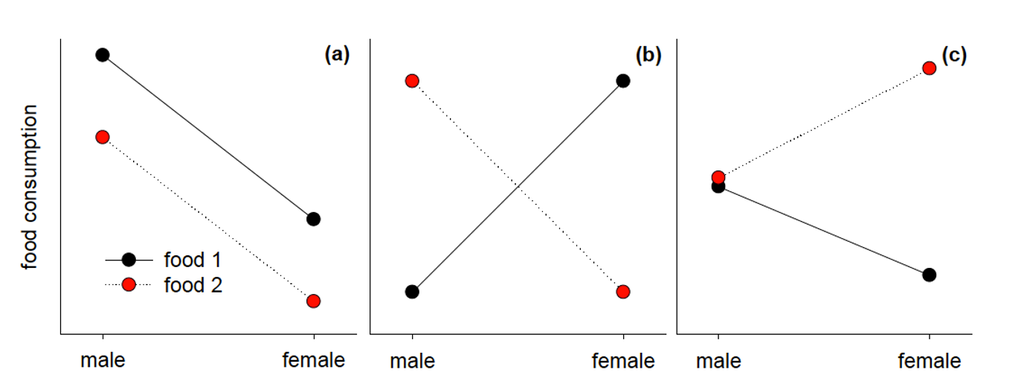

Fig (a) shows a parallel response without interaction, while (b) and (c) show two (of many possible) types of interaction.

# Two-way ANOVA in R

```r
data<-read.table("data/RatsFood.txt",header=TRUE)

tapply(data$cons,list(data$food,data$sex),mean)
```

```
##    female   male
## 1 20.8635 20.010
## 2 19.8795 21.239
```

```r
tapply(data$cons,list(data$food,data$sex),sd)
```

```
##      female     male
## 1 1.2889909 1.182353
## 2 0.8464195 1.142693
```

```r
tapply(data$cons,list(data$food,data$sex),length)     # check if design is balanced
```

```
##   female male
## 1     20   20
## 2     20   20
```

```r
# Make sure factors are recognized properly
data$food<-factor(data$food)
data$sex<-factor(data$sex)

# could check ND tediously in each cell of the design
f1s1<-data$cons[data$food=="1" & data$sex=="male"]

# or after standardisation within each cell
combfac<-factor(paste(data$food,data$sex,sep="_"))
z <- unlist(tapply(data$cons, INDEX=combfac, scale))

shapiro.test(z)
```

```
##
##  Shapiro-Wilk normality test
##
## data:  z
## W = 0.98458, p-value = 0.4505
```

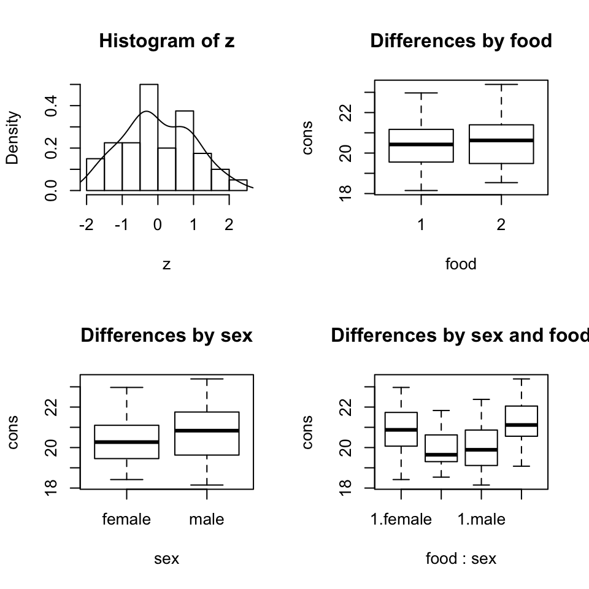

```r
layout(matrix(c(1:4),2,2,byrow = TRUE))
hist(z,freq=FALSE); lines(density(z))
boxplot(cons~food,data=data,main="Differences by food")
boxplot(cons~sex,data=data,main="Differences by sex")
boxplot(cons~food*sex,data=data,main="Differences by sex and food")
```

```r
bartlett.test(cons~combfac,data=data) # testing variance homogeneity
```

```
##
##  Bartlett test of homogeneity of variances
##
## data:  cons by combfac
## Bartlett's K-squared = 3.3712, df = 3, p-value = 0.3379
```

```r
# two-way ANOVA table - BETTER ONLY USE THIS FOR BALANCED DESIGNS !
fit<-aov(cons~food*sex,data=data)
fit
```

```
## Call:
##    aov(formula = cons ~ food * sex, data = data)
##
## Terms:
##                     food      sex food:sex Residuals
## Sum of Squares   0.30013  1.28018 24.48685  96.55093
## Deg. of Freedom        1        1        1        76
##
## Residual standard error: 1.127123
## Estimated effects may be unbalanced
```

```r
summary(fit)
```

```
##             Df Sum Sq Mean Sq F value   Pr(>F)
## food         1   0.30    0.30   0.236    0.628
## sex          1   1.28    1.28   1.008    0.319
## food:sex     1  24.49   24.49  19.275 3.61e-05 ***
## Residuals   76  96.55    1.27
## ---
## Signif. codes:  0 '***' 0.001 '**' 0.01 '*' 0.05 '.' 0.1 ' ' 1
```

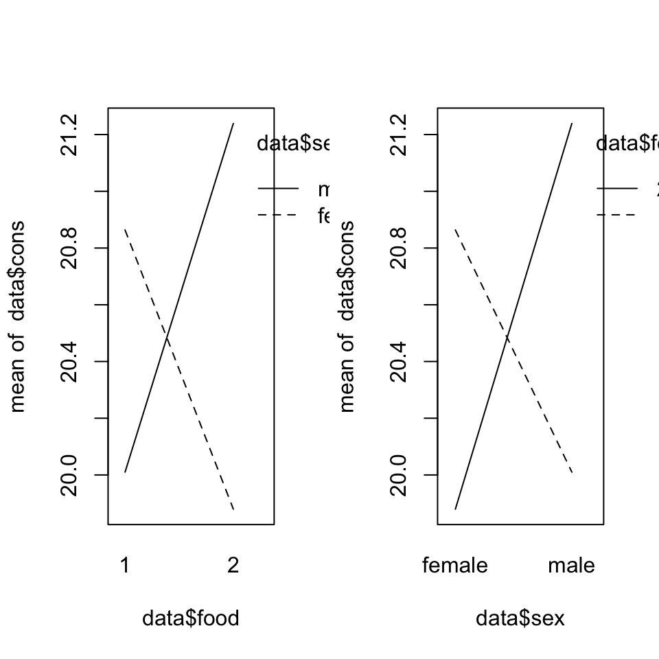

```r
anova(lm(cons~food*sex,data=data))
## Analysis of Variance Table
##
## Response: cons
##           Df Sum Sq Mean Sq F value    Pr(>F)
## food       1  0.300  0.3001  0.2362    0.6283
## sex        1  1.280  1.2802  1.0077    0.3186
## food:sex   1 24.487 24.4868 19.2748 3.607e-05 ***
## Residuals 76 96.551  1.2704
## ---
## Signif. codes:  0 '***' 0.001 '**' 0.01 '*' 0.05 '.' 0.1 ' ' 1

layout(matrix(c(1:2),1,2,byrow = TRUE))
interaction.plot(data$food,data$sex,data$cons)
interaction.plot(data$sex,data$food,data$cons)
```

```r
#######################################
# Post-hoc comparisons between groups #
TukeyHSD(fit)
```

```
##   Tukey multiple comparisons of means
##     95% family-wise confidence level
##
## Fit: aov(formula = cons ~ food * sex, data = data)
##
## $food
##       diff        lwr       upr     p adj
## 2-1 0.1225 -0.3794661 0.6244661 0.6283313
##
## $sex
##              diff        lwr       upr     p adj
## male-female 0.253 -0.2489661 0.7549661 0.3186417
##
## $`food:sex`
##                      diff        lwr         upr     p adj
## 2:female-1:female -0.9840 -1.9202631 -0.04773692 0.0356193
## 1:male-1:female   -0.8535 -1.7897631  0.08276308 0.0867495
## 2:male-1:female    0.3755 -0.5607631  1.31176308 0.7185775
## 1:male-2:female    0.1305 -0.8057631  1.06676308 0.9830986
## 2:male-2:female    1.3595  0.4232369  2.29576308 0.0015454
## 2:male-1:male      1.2290  0.2927369  2.16526308 0.0050128
```

# ANalysis of COVAriance

A combination of ANOVA and regression, can be regarded as:

1. A regression model including a categorical predictor to make room for variation of the regression among groups.
2. An ANOVA model including a *covariate* (= often a variable not interesting but having high influence on the response)

Simplest case: One metric continuous response Y, one factor A (at least 2 levels) and one metric continuous variable X as predictors. In the simplest case we do not assume interaction between A and X.

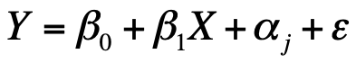

where:

- $\beta_0$ is the intercept
- $\beta_1$ is the slope for the covariate (pooled across all levels of A)
- $\alpha_j$ is the effect of level j of the factor A (relative to a reference level or the overall mean)
- $\epsilon$ is remaining random error

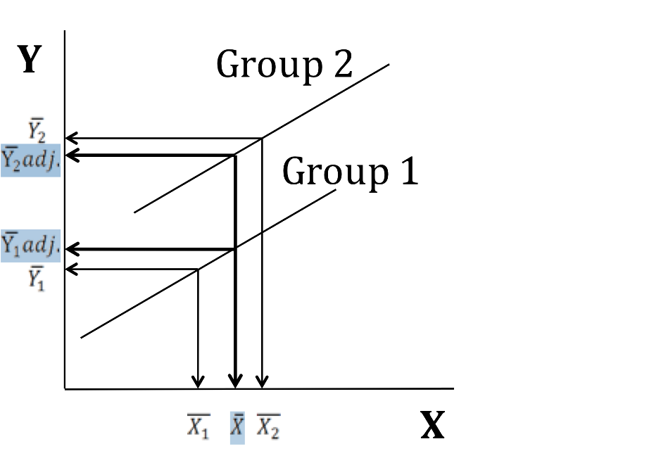

**Adjusted means** are accounting for the effect of the covariate. They represent the group means at the overall grand mean of X. They are classically computed in case of a *nuisance covariate* when the ANOVA-component of the model is important and the range of X covered by the two groups differ.

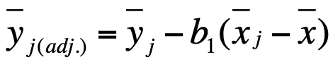

# ANCOVA: Hypotheses and assumptions

Assuming the simplest case of 1 factor and 1 covariate and no interaction included. 2 hypotheses (pairs):

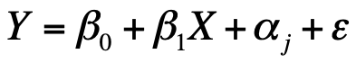

H0: **All adjusted means are identical**, no treatment effects (ANOVA hypothesis but considering simultaneous adjustment with the covariate). Given the assumption of slope homogeneity, this is identical to a test of equality of group intercepts!

H0: **No effect of the covariate** (as in simple linear regression).

Adding an interaction term:

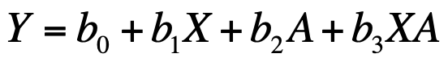

H0: **No interaction**. Equal slopes between groups. This is the easiest way to **test for homogeneity of slopes**!

Assumption and diagnostics as in ANOVA and LR:

- Normal distribution of residuals
- Variance homogeneity of residuals across groups and X
- Conceptual issue: No collinearity between covariate and factor

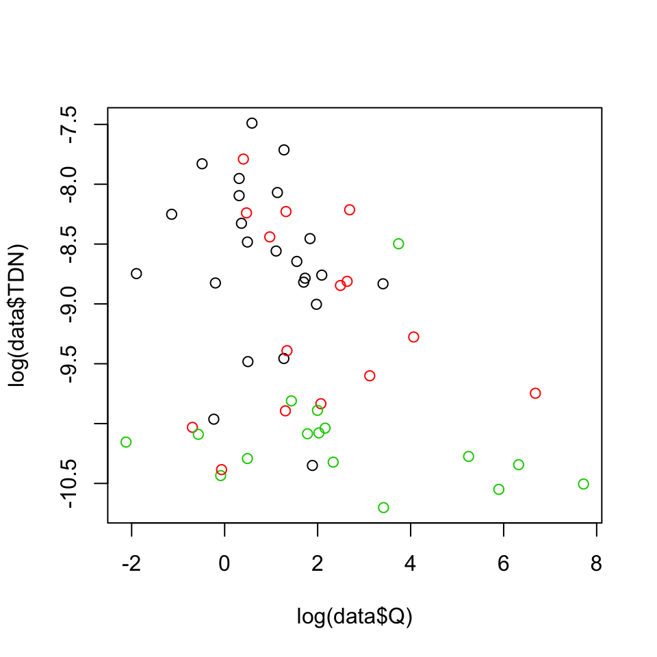

```r
# continuing analysis of log(TDN) in the Mara River
plot(log(data$TDN)~log(data$Q),col=data$landuse) # effect of catchment size?
```

```r
summary(lm(log(TDN)~log(Q),data=data))
```

```
##
## Call:
## lm(formula = log(TDN) ~ log(Q), data = data)
##
## Residuals:
##     Min      1Q  Median      3Q     Max
## -1.5015 -0.7248  0.1641  0.6646  1.5661
##
## Coefficients:
##             Estimate Std. Error t value Pr(>|t|)
## (Intercept) -8.96812    0.15466 -57.987   <2e-16 ***
## log(Q)      -0.14861    0.05942  -2.501   0.0156 *
## ---
## Signif. codes:  0 '***' 0.001 '**' 0.01 '*' 0.05 '.' 0.1 ' ' 1
##
## Residual standard error: 0.8718 on 52 degrees of freedom
## Multiple R-squared:  0.1074, Adjusted R-squared:  0.09021
## F-statistic: 6.255 on 1 and 52 DF,  p-value: 0.01557
```

```r
m1<-lm(log(TDN)~log(Q)+landuse,data=data)
anova(m1)
## Analysis of Variance Table
##
## Response: log(TDN)
##           Df  Sum Sq Mean Sq F value    Pr(>F)
## log(Q)     1  4.7544  4.7544  10.333   0.00229 **
## landuse    2 16.5167  8.2584  17.948 1.333e-06 ***
## Residuals 50 23.0059  0.4601
## ---
## Signif. codes:  0 '***' 0.001 '**' 0.01 '*' 0.05 '.' 0.1 ' ' 1
summary(m1)
```

```
##
## Call:
## lm(formula = log(TDN) ~ log(Q) + landuse, data = data)
##
## Residuals:
##      Min       1Q   Median       3Q      Max
## -1.65826 -0.29533 -0.05748  0.30829  1.67994
##
## Coefficients:
##             Estimate Std. Error t value Pr(>|t|)
## (Intercept) -8.61085    0.14768 -58.307  < 2e-16 ***
## log(Q)      -0.04275    0.04991  -0.857    0.396
## landuseM    -0.42214    0.23136  -1.825    0.074 .
## landuseF    -1.40661    0.23767  -5.918 2.93e-07 ***
## ---
## Signif. codes:  0 '***' 0.001 '**' 0.01 '*' 0.05 '.' 0.1 ' ' 1
##
## Residual standard error: 0.6783 on 50 degrees of freedom
## Multiple R-squared:  0.4804, Adjusted R-squared:  0.4492
## F-statistic: 15.41 on 3 and 50 DF,  p-value: 3.155e-07
```

```r
# with interaction: the effect of catchment size
# could differ between landuses
m2<-lm(log(TDN)~log(Q)*landuse,data=data)
anova(m2) # no interaction
## Analysis of Variance Table
##
## Response: log(TDN)
##                Df  Sum Sq Mean Sq F value   Pr(>F)
## log(Q)          1  4.7544  4.7544  10.006 0.002706 **
## landuse         2 16.5167  8.2584  17.380  2.1e-06 ***
## log(Q):landuse  2  0.1977  0.0988   0.208 0.812949
## Residuals      48 22.8083  0.4752
## ---
## Signif. codes:  0 '***' 0.001 '**' 0.01 '*' 0.05 '.' 0.1 ' ' 1

# adjusted means only make sense when slopes are homogeneous!
common.slope<-coefficients(m1)[2]
adj.m<-tapply(log(data$TDN),INDEX=data$landuse,FUN=mean)-
  common.slope*
  (tapply(log(data$Q),INDEX=data$landuse,FUN=mean)-mean(log(data$Q)))
adj.m
```

```
##          A          M          F
##  -8.682227  -9.104369 -10.088833
```

```r
adj.m-adj.m[1] # these are the differences to reference level=A
```

```
##          A          M          F
##  0.0000000 -0.4221428 -1.4066067
```

```r
# same as in the summary(m1) output

# compare with unadjusted means
m<-tapply(X=log(data$TDN),INDEX=data$landuse,FUN=mean)
m-m[1] # these are the differences of unadjusted means to reference level=large
```

```
##          A          M          F
##  0.0000000 -0.4678338 -1.4818796
```

```r
# --> the inclusion of the covariate has reduced
# the "apparent" differences a bit

# checking assumptions
shapiro.test(m1$res)
```

```
##
##  Shapiro-Wilk normality test
##
## data:  m1$res
## W = 0.98259, p-value = 0.6172
```

```r
bartlett.test(m1$res~data$landuse)
```

```
##
##  Bartlett test of homogeneity of variances
##
## data:  m1$res by data$landuse
## Bartlett's K-squared = 3.1891, df = 2, p-value = 0.203
```

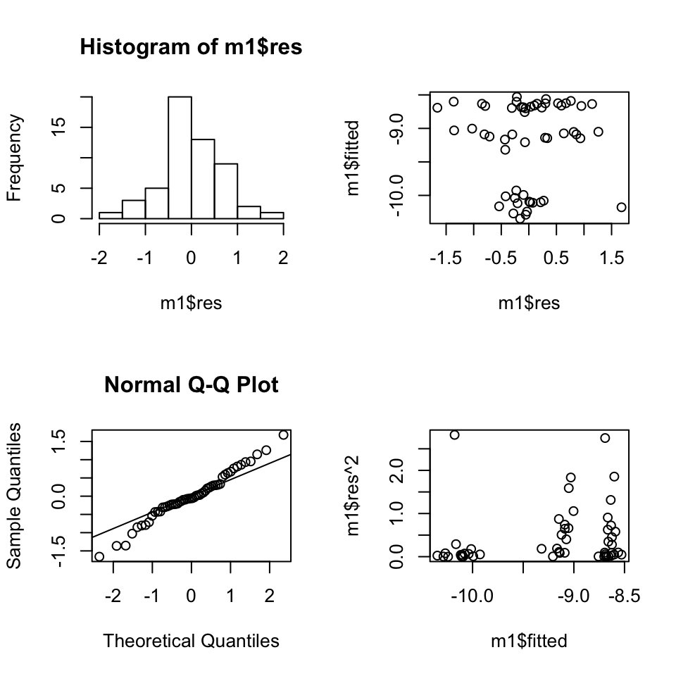

```r
layout(matrix(1:4,2,2))
hist(m1$res)
qqnorm(m1$res); qqline(m1$res)
plot(m1$res,m1$fitted) # unexplained relationship/pattern left?
plot(m1$res^2~m1$fitted) # variances homogeneous? should not show any trend
```

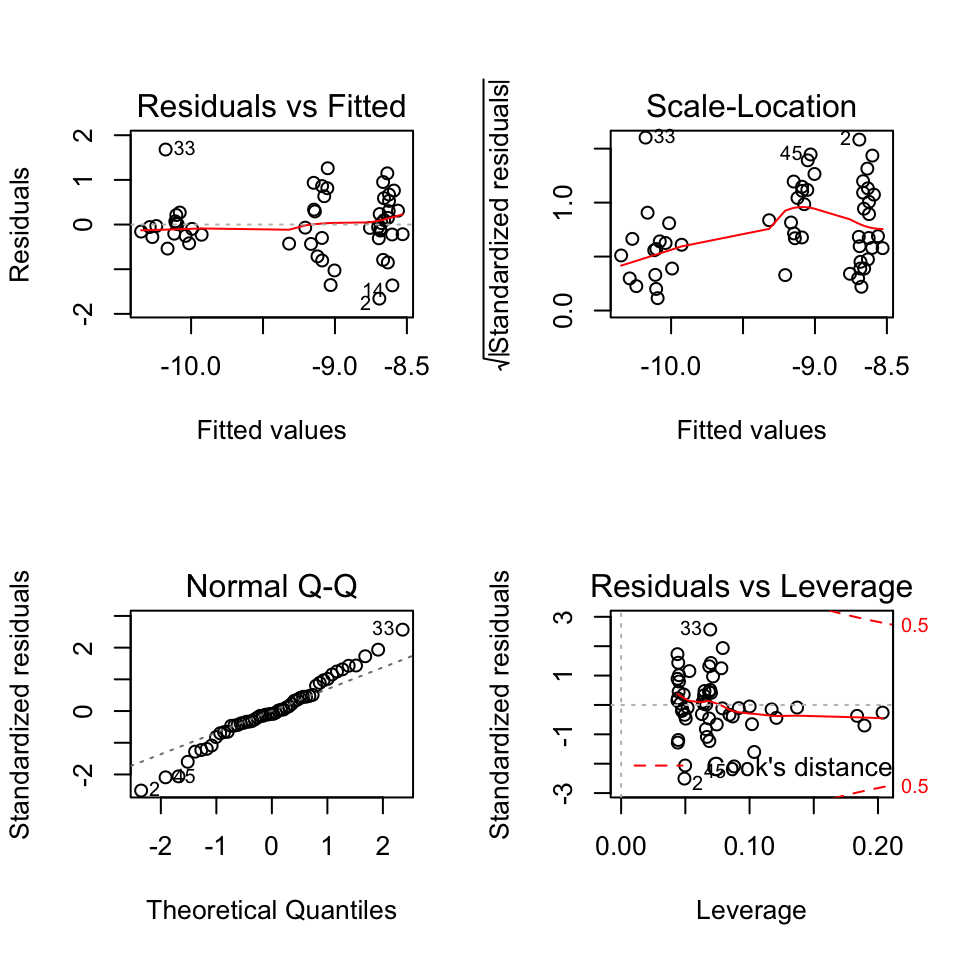

```r
layout(matrix(1:4,2,2))
plot(m1)
```